# Taller 1 - Análisis Avanzado de Datos

Juan Sebastián Cortés Sánchez y Brayan Steven Calderon Adames

**Problema**. El conjunto de datos taller1.txt contiene la información del perfíl genómico de un conjunto de 1200 líneas celulares. Para estas se busca determinar cuáles de los 5000 genes (ubicados en cada columna) son de relevancia para la predicción de la variable respuesta (efectividad del tratamiento anticancer, medida como variable continua). Responda las siguientes preguntas:

```r
library(readr)
library(caTools)
library(glmnet)
```

```r
taller1 <- read.csv("C:/Users/braya/Desktop/Maestria/Segundo semestre/Analisis avanzado de datos/taller1.txt")
```

1. ¿Hay multicolinealidad en los datos? Explique sucintamente.

```r
corr <- cor(taller1)

valores <- vector("list", dim(taller1)[2])

for(i in 1:dim(taller1)[2]){
  frame <- data.frame(corr[,i][(corr[,i] > 0.7) | (corr[,i] < -0.7)])
  names(frame) = c(names(taller1[i]))
  if(dim(frame)[1] > 2){
    valores[[i]] <- frame
  }
}

valores_filtrados <- Filter(Negate(is.null), valores)
valores_filtrados
```

```
## list()
```

Se realizo una revision a las correlaciones columna por columna para encontrar si existen correlaciones altas entre los datos que podrian indicar una posible multicolinealidad, como resultado se obtuvo que no hay una relacion lineal demasiado alta para sospechar sobre esto.

2. Separe aleatoriamente (pero guarde la semilla) su conjunto de datos en dos partes.
- Entrenamiento: 1000 líneas celulares.
- Prueba: 200 líneas celulares

```r
# Fijando la semilla
set.seed(123)

# Separando los datos en entrenamiento y prueba
sample <- sample.split(taller1$y, SplitRatio = 1000/1200)
train  <- subset(taller1, sample == TRUE)
test   <- subset(taller1, sample == FALSE)
```

Se coloco una semilla de 123 y se aleatorizaron los datos con las condiciones propuestas para el ejercicio.

3. Usando los 1000 datos de entrenamiento, determine los valores de $\lambda_r$ y $\lambda_l$ de regresión ridge y lasso, respectivamente, que minimicen el error cuadrático medio (ECM) mediante validación externa. Utilice el método de validación externa que considere más apropiado.

```r
# Definir la variable objetivo
y <- train$y
y_test <- test$y

# Definir la matriz de variables predictoras
x <- data.matrix(train[,2:5001])
x_test <- data.matrix(test[,2:5001])
```

Se definen las variables para poder ingresarlas a los modelos ridge y lasso tanto entradas de test como de entrenamiento.

#### Regresión Ridge

```r
# Entrenar modelo usando k-fold cross-validation con k=10
cv_model_ridge <- cv.glmnet(x, y, alpha = 0)
```

```r
best_lambda_ridge <- cv_model_ridge$lambda.min
best_lambda_ridge
```

```
## [1] 11.28422
```

El lambda mas pequeño que minimiza el error cuadratico medio (ECM) en el conjunto de datos de entrenamiento es 11.28422

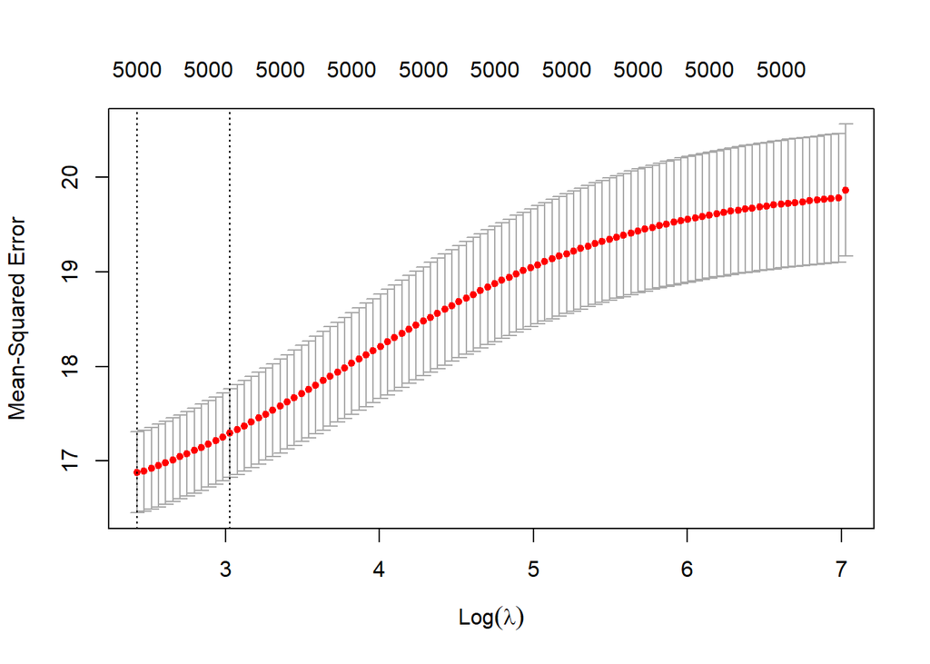

```r
plot(cv_model_ridge)
```

#### Regresión Lasso

```r
# Entrenar modelo usando k-fold cross-validation con k=10
cv_model_lasso <- cv.glmnet(x, y, alpha = 1)
```

```r
best_lambda_lasso <- cv_model_lasso$lambda.min
best_lambda_lasso
```

```
## [1] 0.06609191
```

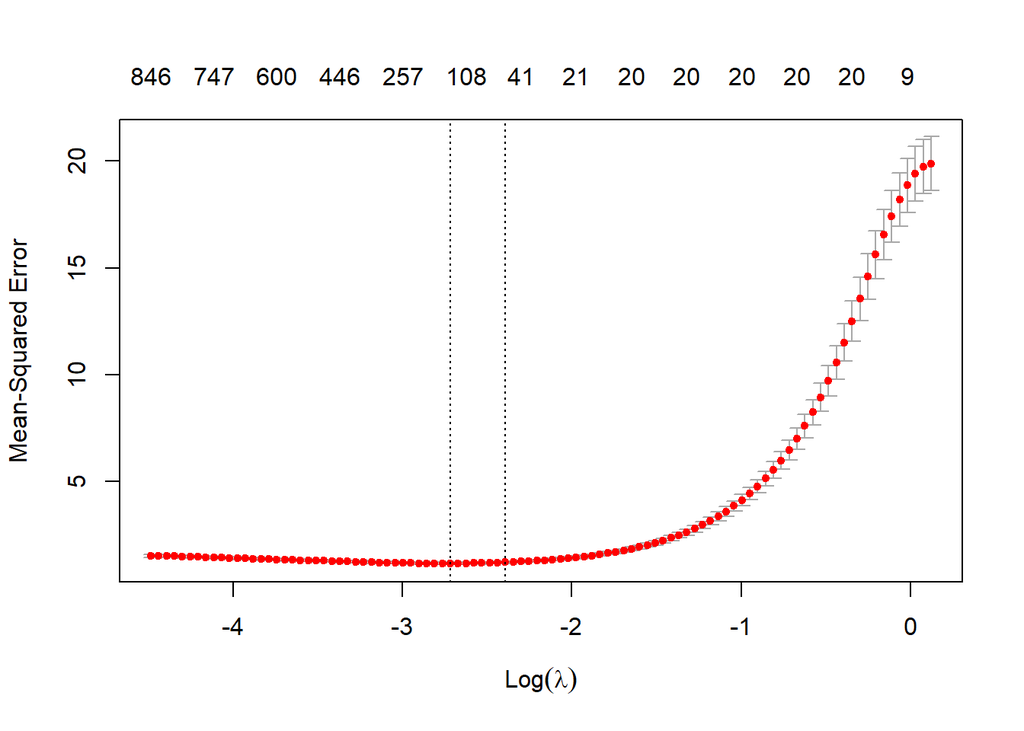

```r
plot(cv_model_lasso)
```

4. Ajuste la regresión ridge y lasso con los valores estimados de $\lambda_r$ y $\lambda_l$ obtenidos en (3) usando los 1000 datos de entrenamiento.

#### Regresión Ridge

```r
best_model_ridge <- glmnet(x, y, alpha = 0, lambda = best_lambda_ridge)
```

#### Regresión Lasso

```r
best_model_lasso <- glmnet(x, y, alpha = 1, lambda = best_lambda_lasso)
```

5. Para los modelos ajustados en (4) determine el más apropiado para propositos de predicción. Considere únicamente el ECM en los 200 datos de prueba para su decisión.

#### Regresión Ridge

```r
# Use best lambda to predict test data
ridge_pred = predict(best_model_ridge, s = best_lambda_ridge, newx = x_test)

# Calculate test MSE
mean((ridge_pred - y_test)^2)
```

```
## [1] 19.36293
```

#### Regresión Lasso

```r
# Use best lambda to predict test data
lasso_pred = predict(best_model_lasso, s = best_lambda_lasso, newx = x_test)

# Calculate test MSE
mean((lasso_pred - y_test)^2)
```

```
## [1] 1.390995
```

6. Ajuste el modelo seleccionado en (5) para los 1200 datos. Note que en este punto ya tiene un $\lambda$ estimado y un modelo seleccionado.

```r
# Definir la variable objetivo
y <- taller1$y

# Definir la matriz de variables predictoras
x <- data.matrix(taller1[,2:5001])
```

```r
last_model <- glmnet(x, y, alpha = 1, lambda = best_lambda_lasso)
```

7. Grafique las trazas de los coeficientes en función de la penalización para el modelo ajustado en (6).

```r
# Display coefficients using lambda chosen by CV
lasso_coef = predict(last_model, type = "coefficients", s = best_lambda_lasso)[1:20,]

lasso_coef_2 = cbind(lasso_coef)
lasso_coef_2
```

```
##              lasso_coef
## (Intercept) -0.05612708
## V1           0.89003432
## V2           0.94461905
## V3           0.92713130
## V4           0.92258728
## V5           0.95850606
## V6           0.95495044
## V7           0.94076363
## V8           0.88736963
## V9           0.88457073
## V10          0.93206522
## V11          0.96492674
## V12          0.89079645
## V13          0.87649452
## V14          0.94200408
## V15          0.92430358
## V16          0.90633998
## V17          0.98960376
## V18          0.94622832
## V19          0.94276169
```

[figure not shown]

```r
plot(last_model, xvar = "lambda")
axis(1, at = c(-1,0,1))
```

```r
# axis(2, at = c(-1,-0.5,0,0.5,1))
```

8. En un parrafo resuma los resultados obtenidos dado el objetivo inicial del estudio.

Si se comparan los valores de MSE (Mean Squared Error) de los modelos Lasso y Ridge, se puede concluir que el modelo Lasso tiene un mejor ajuste a los datos que el modelo Ridge.

El MSE es una medida del error cuadrático medio entre las predicciones del modelo y los valores reales. Un MSE más bajo indica que el modelo tiene un mejor ajuste a los datos y es capaz de predecir con mayor precisión los valores de la variable dependiente.

En este caso, un MSE de 1.390995 para el modelo Lasso indica que las predicciones del modelo tienen un error cuadrático medio de aproximadamente 1.4 unidades en la escala de la variable dependiente. Por otro lado, un MSE de 19.36293 para el modelo Ridge indica que las predicciones del modelo tienen un error cuadrático medio de aproximadamente 19.4 unidades en la escala de la variable dependiente.

Por lo tanto, se puede concluir que el modelo Lasso tiene un mejor ajuste a los datos que el modelo Ridge y es capaz de predecir con mayor precisión los valores de la variable dependiente.